# project_unit_3

2025-04-16

Esta actividad tiene como fin desarrollar un modelo de regresión simple con datos obtenidos del respositorio de datos UC Irvine. Para este ejercicio se han utilizado las calificaciones de las asignatura de Matemáticas y Portugués de dos escuelas de secundaria de Portugal. El conjunto de datos no cuenta con datos perdidos.

En este informe se empieza por crear dos tablas que muestran las variables cuantitativas que tiene cada conjunto de datos. Con esta información se pueden empezar a establecer posibles correlaciones presentes en las variables para posteriormente realizar el modelo de regresión lineal.

El problema a resolver en este ejercicio es la predicción de la nota correspondiente al último o tercer periodo partiendo de las notas anteriores, según el nivel de la correlación existente entre las variables.

# Exploración de datos

Este es el primer paso en cualquier proyecto, pues es necesario explorar el conjunto de datos para conocer las variables que posee cada conjunto de datos y el tipo de estas. En este caso, para practicidad, no se manipula el merge hecho originalmente, sino que se usa cada una de las bases para aplicar los modelos a cada base.

En este primer momento, se filtran las variables numéricas, ya que, como se dijo al inicio, solo se usarán los datos cuantitativos en este modelo.

Esta tabla corresponde al resumen de las variables cuantitativas que tiene el conjunto de datos de estudiantes de la asignatura de Portugués. En esta se puede observar que el grupo de estudiantes está conformado por personas entre los 15 y 22 años de edad. Esta distribución es coherente con el universo que compone el grupo de datos, puesto que son datos extraídos de escuelas de Portugal.

|  | age | Medu | Fedu | traveltime | studytime | failures | famrel | freetime | goout | Dalc | Walc | health | absences | G1 | G2 | G3 |
| --- | --- | --- | --- | --- | --- | --- | --- | --- | --- | --- | --- | --- | --- | --- | --- | --- |
|  | Min. :15.00 | Min. :0.000 | Min. :0.000 | Min. :1.000 | Min. :1.000 | Min. :0.0000 | Min. :1.000 | Min. :1.00 | Min. :1.000 | Min. :1.000 | Min. :1.00 | Min. :1.000 | Min. : 0.000 | Min. : 0.0 | Min. : 0.00 | Min. : 0.00 |
|  | 1st Qu.:16.00 | 1st Qu.:2.000 | 1st Qu.:1.000 | 1st Qu.:1.000 | 1st Qu.:1.000 | 1st Qu.:0.0000 | 1st Qu.:4.000 | 1st Qu.:3.00 | 1st Qu.:2.000 | 1st Qu.:1.000 | 1st Qu.:1.00 | 1st Qu.:2.000 | 1st Qu.: 0.000 | 1st Qu.:10.0 | 1st Qu.:10.00 | 1st Qu.:10.00 |
|  | Median :17.00 | Median :2.000 | Median :2.000 | Median :1.000 | Median :2.000 | Median :0.0000 | Median :4.000 | Median :3.00 | Median :3.000 | Median :1.000 | Median :2.00 | Median :4.000 | Median : 2.000 | Median :11.0 | Median :11.00 | Median :12.00 |
|  | Mean :16.74 | Mean :2.515 | Mean :2.307 | Mean :1.569 | Mean :1.931 | Mean :0.2219 | Mean :3.931 | Mean :3.18 | Mean :3.185 | Mean :1.502 | Mean :2.28 | Mean :3.536 | Mean : 3.659 | Mean :11.4 | Mean :11.57 | Mean :11.91 |
|  | 3rd Qu.:18.00 | 3rd Qu.:4.000 | 3rd Qu.:3.000 | 3rd Qu.:2.000 | 3rd Qu.:2.000 | 3rd Qu.:0.0000 | 3rd Qu.:5.000 | 3rd Qu.:4.00 | 3rd Qu.:4.000 | 3rd Qu.:2.000 | 3rd Qu.:3.00 | 3rd Qu.:5.000 | 3rd Qu.: 6.000 | 3rd Qu.:13.0 | 3rd Qu.:13.00 | 3rd Qu.:14.00 |
|  | Max. :22.00 | Max. :4.000 | Max. :4.000 | Max. :4.000 | Max. :4.000 | Max. :3.0000 | Max. :5.000 | Max. :5.00 | Max. :5.000 | Max. :5.000 | Max. :5.00 | Max. :5.000 | Max. :32.000 | Max. :19.0 | Max. :19.00 | Max. :19.00 |

En cuanto a las calificaciones (G1, G2 y G3), se puede notar que los estudiantes obtuvieron calificaciones de 0 a 19 puntos. En promedio, el periodo con una nota más alta es el tercero, con una media de 11,91 y mediana de 12. Salvo el primer cuartil, los demás presentan calificaciones más altas que los otros.

La siguiente tabla corresponde al resumen de las variables cuantitativas que tiene el conjunto de datos de estudiantes de la asignatura de Matemáticas. Al igual que el anterior, presenta un grupo de estudiantes que va desde los 15 a los 22 años de edad.

|  | age | Medu | Fedu | traveltime | studytime | failures | famrel | freetime | goout | Dalc | Walc | health | absences | G1 | G2 | G3 |
| --- | --- | --- | --- | --- | --- | --- | --- | --- | --- | --- | --- | --- | --- | --- | --- | --- |
|  | Min. :15.0 | Min. :0.000 | Min. :0.000 | Min. :1.000 | Min. :1.000 | Min. :0.0000 | Min. :1.000 | Min. :1.000 | Min. :1.000 | Min. :1.000 | Min. :1.000 | Min. :1.000 | Min. : 0.000 | Min. : 3.00 | Min. : 0.00 | Min. : 0.00 |
|  | 1st Qu.:16.0 | 1st Qu.:2.000 | 1st Qu.:2.000 | 1st Qu.:1.000 | 1st Qu.:1.000 | 1st Qu.:0.0000 | 1st Qu.:4.000 | 1st Qu.:3.000 | 1st Qu.:2.000 | 1st Qu.:1.000 | 1st Qu.:1.000 | 1st Qu.:3.000 | 1st Qu.: 0.000 | 1st Qu.: 8.00 | 1st Qu.: 9.00 | 1st Qu.: 8.00 |
|  | Median :17.0 | Median :3.000 | Median :2.000 | Median :1.000 | Median :2.000 | Median :0.0000 | Median :4.000 | Median :3.000 | Median :3.000 | Median :1.000 | Median :2.000 | Median :4.000 | Median : 4.000 | Median :11.00 | Median :11.00 | Median :11.00 |
|  | Mean :16.7 | Mean :2.749 | Mean :2.522 | Mean :1.448 | Mean :2.035 | Mean :0.3342 | Mean :3.944 | Mean :3.235 | Mean :3.109 | Mean :1.481 | Mean :2.291 | Mean :3.554 | Mean : 5.709 | Mean :10.91 | Mean :10.71 | Mean :10.42 |
|  | 3rd Qu.:18.0 | 3rd Qu.:4.000 | 3rd Qu.:3.000 | 3rd Qu.:2.000 | 3rd Qu.:2.000 | 3rd Qu.:0.0000 | 3rd Qu.:5.000 | 3rd Qu.:4.000 | 3rd Qu.:4.000 | 3rd Qu.:2.000 | 3rd Qu.:3.000 | 3rd Qu.:5.000 | 3rd Qu.: 8.000 | 3rd Qu.:13.00 | 3rd Qu.:13.00 | 3rd Qu.:14.00 |
|  | Max. :22.0 | Max. :4.000 | Max. :4.000 | Max. :4.000 | Max. :4.000 | Max. :3.0000 | Max. :5.000 | Max. :5.000 | Max. :5.000 | Max. :5.000 | Max. :5.000 | Max. :5.000 | Max. :75.000 | Max. :19.00 | Max. :19.00 | Max. :20.00 |

A diferencia con las notas de Portugués, las calificaciones en promedio fueron más altas en el primer periodo, pues no se obtuvieron calificaciones de cero. Sin embargo, en el tercero hubo calificaciones más altas, de veinte puntos, pero también de cero. La mediana ha sido la misma en todos los casos.

Ahora bien, se parte del hecho que cada cero es una calificación legítima, no una ausencia de dato. Es decir, por diversos motivos, que pueden ser también que los estudiantes no se presentaron, hubo alguna penalidad u otro motivo; es calificación puesta por el docente, no ausencia de dato.

Los datos anteriores fueron filtrados, de tal forma que se obtienen solamente los datos cuantitativos, ya que, para este caso, el modelo a crear solo usará este tipo de datos y para que las primeras tablas realizadas fueran más sencillas de visualizar. En adición a lo anterior, en las tablas se puede observar que hay estudiantes que obtuvieron calificaciones de cero, de donde se entiende que hay datos atípicos (outliers), razón por la cual se omiten a continuación para evitar dificultades con el modelo.

En los pasos anteriores se han seleccionado solo los valores cuantitativos, numéricos, y luego se filtraron en las calificaciones, que son las variables de interés, para suprimir los valores atípicos en este modelo. El siguiente paso es hacer una gráfica para entender el coheficiente correlación de Pearson, distribución y linealidad que tienen las variables entres sí. Con este paso, se puede observar si se cumplen algunos requisitos, como el R cuadrado.

En síntesis, permite conocer si existe o no una relación entre las variables, positiva o negativa, que lleva a establecer si cuando se incrementa una variable se puede incrementar otra o disminuir; si el comportamiento de de las variables es el mismo, que se incrementan o disminuyen al mismo tiempo, o contrario, que una se incrementa y otra disminuye.

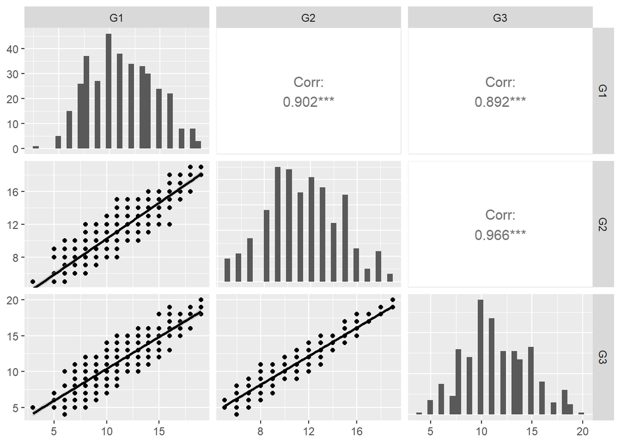

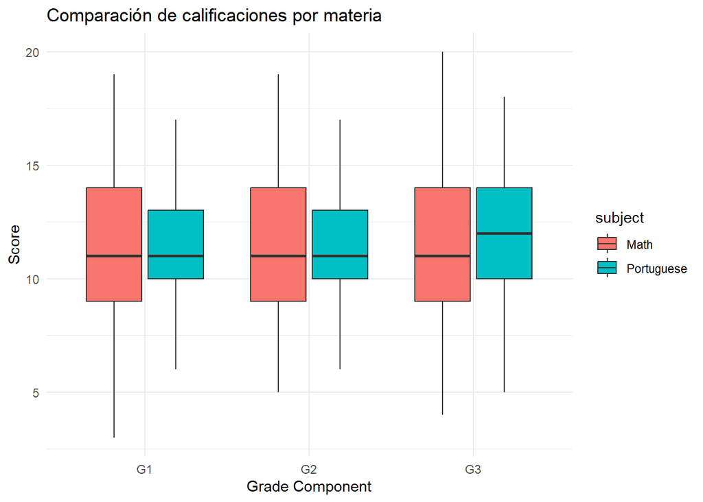

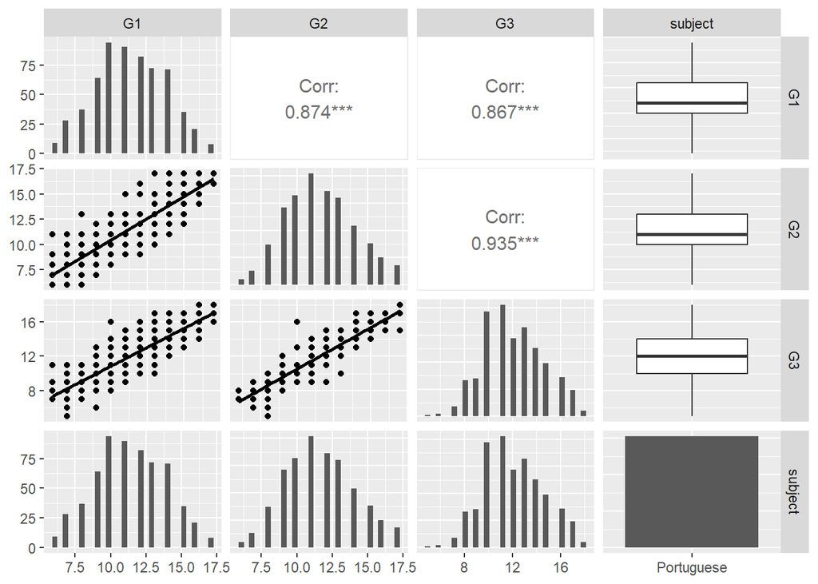

Teniendo en cuenta lo anterior, se puede ver en que las variables G3 y G2 tienen una correlación de 0,966 en la asignatura de Matemáticas; para Portugués es de 0,934. En ambos conjuntos de datos hay una correlación muy fuerte, de casi 1, lo que quiere decir que es casi exacta la relación entre varibales (como lo exhiben los gráficos de puntos).

Otro aspecto a destacar de estos datos es que los histogranmas muestran que hay una distribución que tiende a normal entre las variables, relacionadas entre ellas. En cada variable adicional se puede evidenciar un comportamiento similar (como se muestra en los anexos).

# Modelo de regresión lineal simple

El modelo de regresión lineal simple es por ende, se busca explicar la relación que hay entre una variable dependiente el el conjunto de datos (Carrollo, 2011).

```
[1] 0.891805
```

```
[1] 0.9655825
```

```
[1] 0.8665954
```

```
[1] 0.9348894
```

La regresión lineal para el conjunto de datos de Matemáticas se muestra a continuación. Para este ejercicio se busca predecir la nota correspondiente a G3 partiendo de G2. Los resultados de este modelo se muestran a continuación.

```
Call:
lm(formula = G3 ~ G2, data = student_mat_num_filtrado)

Residuals:
    Min      1Q  Median      3Q     Max
-2.2172 -0.1978 -0.1494  0.8119  2.8022

Coefficients:
            Estimate Std. Error t value Pr(>|t|)
(Intercept)  0.27529    0.16686    1.65   0.0999 .
G2           0.99031    0.01416   69.95   <2e-16 ***
---
Signif. codes:  0 '***' 0.001 '**' 0.01 '*' 0.05 '.' 0.1 ' ' 1

Residual standard error: 0.8407 on 355 degrees of freedom
Multiple R-squared:  0.9323,    Adjusted R-squared:  0.9322
F-statistic:  4893 on 1 and 355 DF,  p-value: < 2.2e-16
```

El resumen anterior explica que unos residuos de que llegan a casi 3 puntos (máximo de 2,80 y mínimo de -2,21), pero que la mayoría están entre -0,19 y 0,81 (que es bastante acertado). Sobre los coeficientes indican que, cuando el valor estimado del intercepto es cero. Se espera que por cada punto que crezca G2, G3 lo haga en 0,99 puntos. el valor de pr muestra que es altamente significativo estadísticamente; en otras palabras, hay una alta evidencia de que G2 esté relacionado con G3.

Este modelo permite explicar en un 93,23 % la variabilidad de las notas de la variable G3. Teniendo en cuenta que esto es un ejercicio con solo una variable, es un buen resultado. El error estándar es de 0,84, lo que es pequeño dado que la escala es hasta veinte.

Este modelo es altamente significativo y respresenta una relación casi de 1:1.

La regresión lineal para el conjunto de datos de Portugués se muestra a continuación. Para este ejercicio se busca predecir la nota correspondiente a G3 partiendo de G2. Los resultados de este modelo se muestran a continuación.

```
Call:
lm(formula = G3 ~ G2, data = student_por_num_filtrado)

Residuals:
    Min      1Q  Median      3Q     Max
-3.5840 -0.4813 -0.3100  0.5530  5.4845

Coefficients:
            Estimate Std. Error t value Pr(>|t|)
(Intercept)  0.85813    0.17639   4.865 1.46e-06 ***
G2           0.96574    0.01486  65.000  < 2e-16 ***
---
Signif. codes:  0 '***' 0.001 '**' 0.01 '*' 0.05 '.' 0.1 ' ' 1

Residual standard error: 0.8874 on 609 degrees of freedom
Multiple R-squared:  0.874, Adjusted R-squared:  0.8738
F-statistic:  4225 on 1 and 609 DF,  p-value: < 2.2e-16
```

Ambos modelos muestran, como se expuso en el inicio de este informe, ambas variables, que son calificaciones, tienen una relación muy fuerte por su naturaleza. Ahora bien, es necesario realizar un análisis de diagnóstico, el cual se muestra a continuación.

# Análisis de diagnóstico

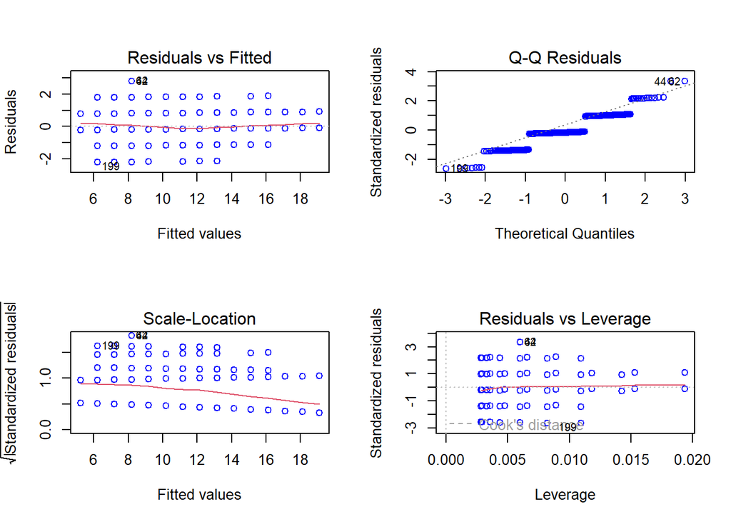

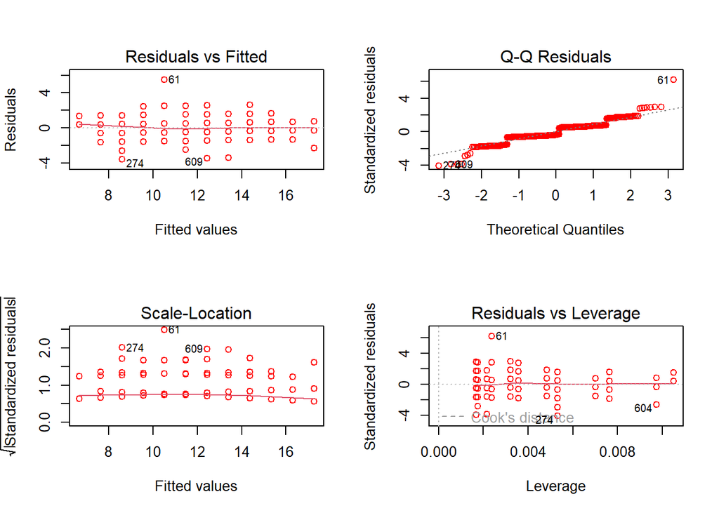

# Análisis de datos atípicos

```
  G2 G3 predicciones   residual
1  6  6     6.217169 -0.2171693
2  5  6     5.226855  0.7731447
3  8 10     8.197797  1.8022029
4 14 15    14.139681  0.8603192
5 10 10    10.178425 -0.1784250
6 15 15    15.129995 -0.1299948
```

En esta tabla se pueden ver las primeras seis filas usando el modelo para la calificación de la asignatura de Matemáticas. En esta se puede ver que, aunque el modelo no logra predecir con exactitud la nota que se obtendrá, sí se obtiene un valor relativamente cercano (menor de dos puntos positivos de un punto negativo), tal como se vio en los gráficos anteriores.

```
  G2 G3 predicciones   residual
1 11 11     11.48127 -0.4812657
2 13 12     13.41274 -1.4127442
3 14 14     14.37848 -0.3784834
4 13 13     13.41274 -0.4127442
5 12 13     12.44700  0.5529951
6 12 13     12.44700  0.5529951
```

En el caso de Portugués, vemos que también hay una predicción que, aunque no es perfecta, es cercana al valor real (menos de un punto positivo y menos de uno y medio negativo), con lo que también se observa un comportamiento similar al de los gráficos anteriormente expuestos.

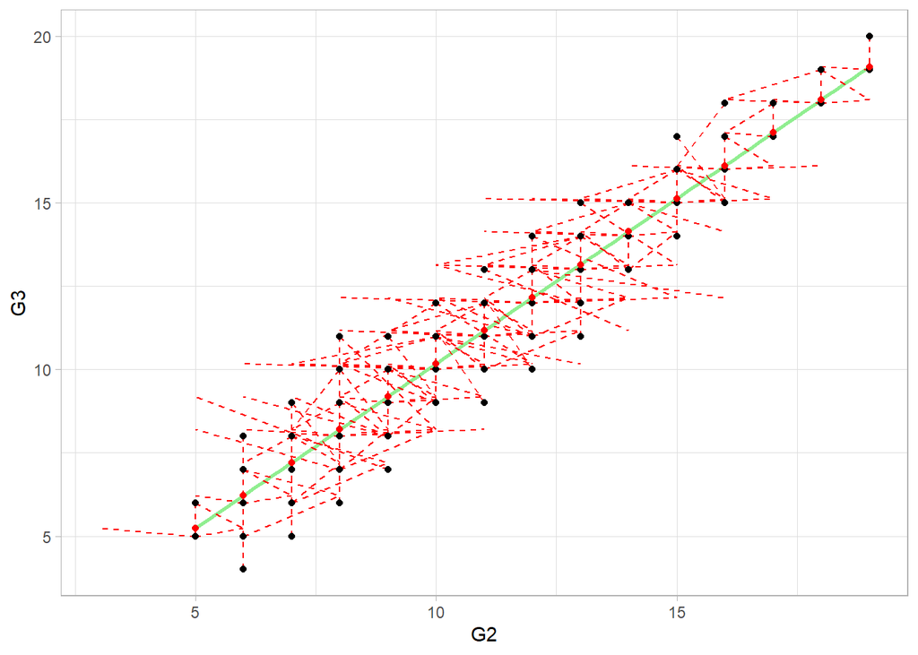

En esta gráfca se puede observar la forma en que se relaciona G3 con G2 de la asignatura de Matemáticas, como el presente modelo lo predice. Aquí se puede ilustrar que hay una relación fuerte entre las variables (como se explica la inicio de este documento), las predicciones son más o menos precisas y que los errores no parecieran que tuvieran patrón. Lo anterior quiere decir que las predicciones son bastante buenas.

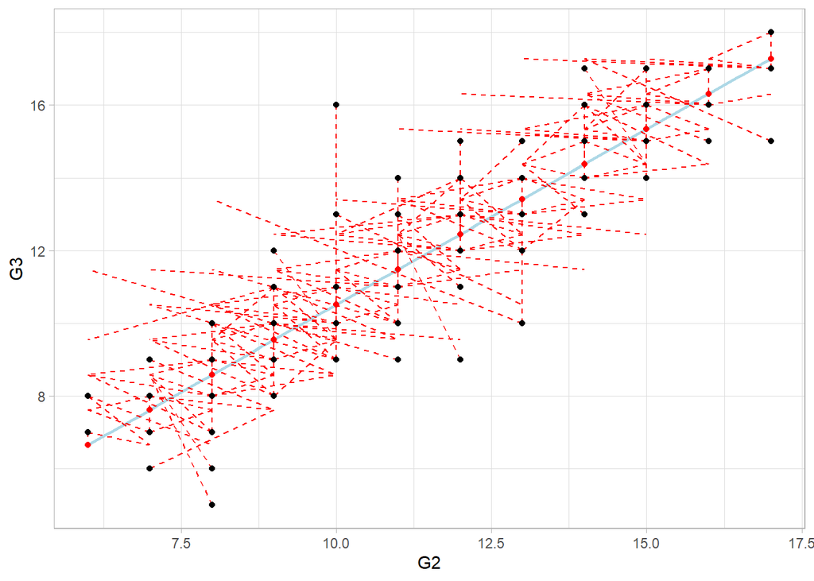

En esta gráfca se puede observar la forma en que se relaciona G3 con G2 para la asignatura de Portugués, como el presente modelo lo predice. Aquí se puede ilustrar que hay una relación fuerte entre las variables (como se explica la inicio de este documento), las predicciones son más o menos precisas y que los errores no parecieran que tuvieran patrón. Lo anterior quiere decir que las predicciones son bastante buenas.

```
    Shapiro-Wilk normality test

data:  resid_mat
W = 0.89793, p-value = 9.682e-15
```

De este test de la asignatura de Matemáticas se puede determinar estadísticamente que los residuos no tienen una distribución normal, como se menciona previamente. Por esto, no se puede tomar la hipótesis nula. Ahora bien, es necesario mencionar nuevamente que esto se presenta puesto que, para efectos de la asignatura, se han tomado solo dos variables en el modelo, por lo que estos últimos puntos presentan este comportamiento.

```
    Shapiro-Wilk normality test

data:  resid_por
W = 0.90891, p-value < 2.2e-16
```

De este test de la asignatura de Portugués se puede determinar estadísticamente que los residuos no tienen una distribución normal, como se menciona previamente. Por esto, no se puede tomar la hipótesis nula. Ahora bien, es necesario mencionar nuevamente que esto se presenta puesto que, para efectos de la asignatura, se han tomado solo dos variables en el modelo, por lo que estos últimos puntos presentan este comportamiento.

```
    studentized Breusch-Pagan test

data:  modelo_mat
BP = 12.297, df = 1, p-value = 0.0004536
```

Para este caso, se muestra con el Breusch-Pagan test de la asignatura de Matemáticas que no se presenta una homocedasticidad, que los errores no tienen varianza constante y que en algunas partes los errores son o más grandes o más pequeños.

```
    studentized Breusch-Pagan test

data:  modelo_por
BP = 3.4649, df = 1, p-value = 0.06268
```

# Intervalos de confianza

Es importante aclarar que, para el presente ejercicio, el modelo de regresión se construyó únicamente con dos variables (G2 como predictora y G3 como respuesta en cada asignatura). Debido a esta simplicidad, se presentan limitaciones a la hora de calcular intervalos de confianza con plena validez, especialmente si no se cumplen los supuestos fundamentales de la regresión, como la normalidad de los residuos y la homocedasticidad.

Aunque en otros casos sería posible ajustar el modelo incorporando más variables explicativas o aplicando transformaciones en el código, en este ejemplo (dado su carácter introductorio y práctico) se ha decidido mantener el enfoque simple. Por esta razón, esto restringe la posibilidad de mejorar la precisión del modelo o de obtener inferencias más robustas.

# Discusión y conclusiones

A pesar de haberse intentado aplicar transformaciones (como el logaritmo) y otras estrategias para mejorar el ajuste del modelo, no fue posible cumplir completamente con los supuestos clásicos de la regresión lineal, quizás por los dicho previamente.

No obstante, dado que se trata de un ejercicio con fines académicos y prácticos, se conserva el modelo en su forma original.

La alta correlación observada entre las calificaciones (G1, G2 y G3) es consistente con la lógica del sistema educativo, en el que las notas de cada periodo reflejan una progresión continua del desempeño estudiantil. En este sentido, no sería posible contar con la nota final (G3) sin haber pasado previamente por los periodos anteriores (G1 y G2), como también lo han planteado Cortes y Silva (2008). En este orden de ideas, estas variables tienen una relación natural, por ello su correlación es tan fuerte.

# Referencias bibliográficas

Carrollo, M. (2011). Regresión lineal simple. Departamento de Estadística e Investigación Operativa. Recuperado de: http://eio.usc.es/eipc1/BASE/BASEMASTER/FORMULARIOS-PHP-DPTO/MATERIALES/Mat_50140116_Regr_%20simple_2011_12.pdf

Cortez, P. y Silva, A. (2008). Student Performance [Dataset]. UCI Machine Learning Repository. doi://doi.org/10.24432/C5TG7T.

# Anexos

En este apartado se escribe todo el código que no se usó en el cuerpo del informe por dos razones: la primera, los requisitos de extensión para esta actividad no permiten que estén ahí; la segunda, no son tan relevantes para el informe, aunque dan cuenta de algunas características del conjunto de datos escogido para esta actividad.

El primer código que se escribe es aquel que permite observar las variables cuantitativas escogidas del conjunto de datos que corresponde a la asignatura de Portugués. Para esta variable se ha escogido usar el color “lightgreen” para diferenciarla de Matemáticas. Las variables escogidas son edad (age), tiempo dedicado a estudiar (studytime), el corte 1 (G1), el corte 2 (G2) y le corte 3 (G3)

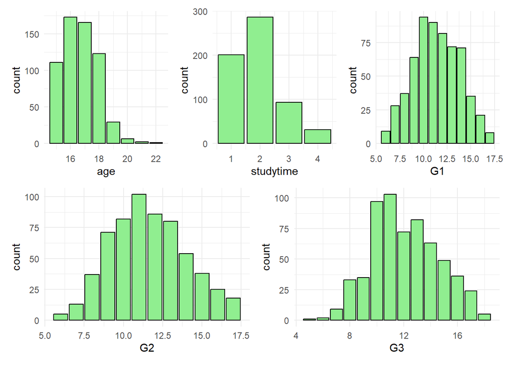

El siguiente código es el que permite, al igual que el anterior, conocer las variables cuantitativas escogidas del conjunto de datos utilizado en el presente ejercicio. Para este caso, ha sido de la asignatura de Matemáticas, para la cual se usa el color “lightblue”. Las variables escogidas son edad (age), tiempo dedicado a estudiar (studytime), el corte 1 (G1), el corte 2 (G2) y le corte 3 (G3)

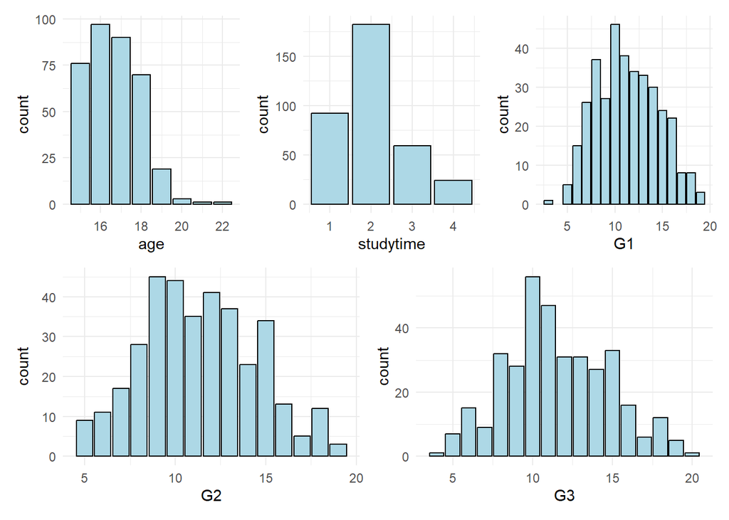

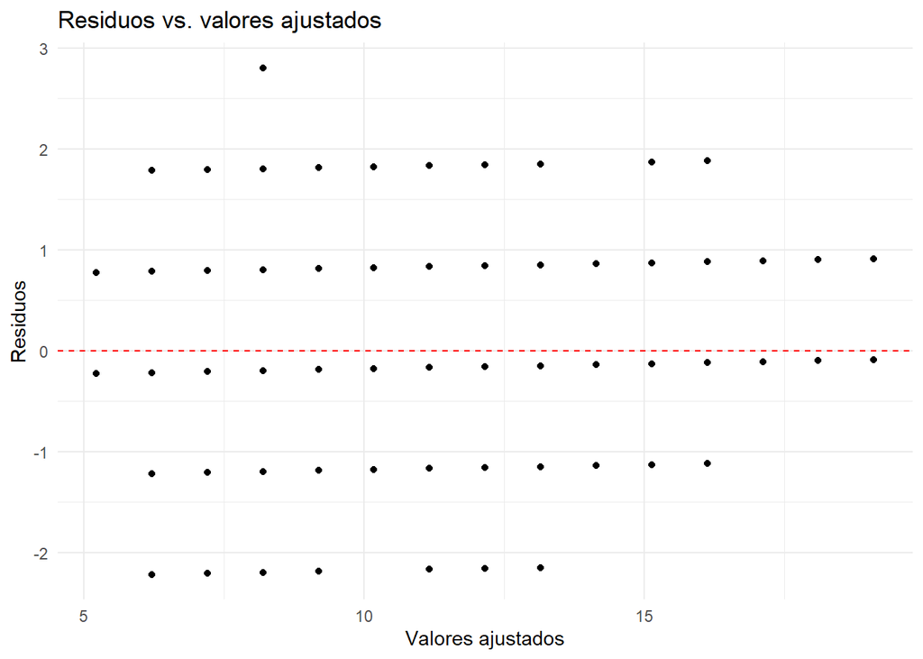

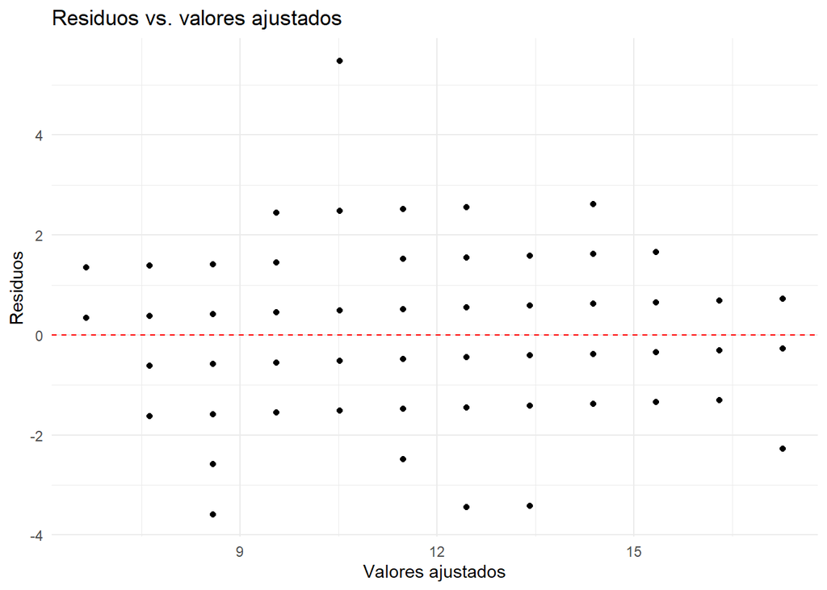

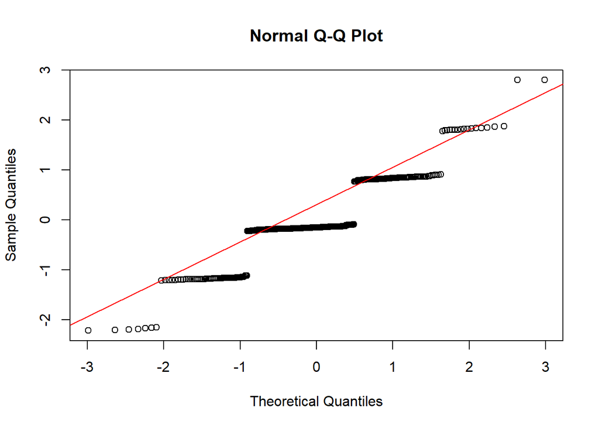

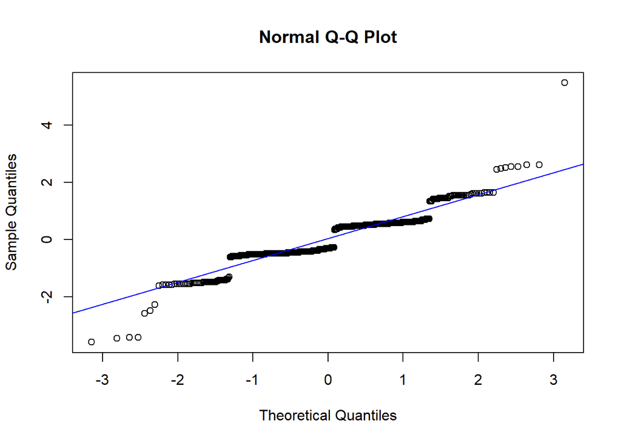